# Final Project - Predicting Season Points in La Liga

Osarodion

4/18/2022

# Advanced Business Analytics – Final Project

## Team Members

Osarodion Ogbebor Evans

## Project Title

Predicting Season Points for the 2017/2018 Spanish la liga season

## Type of Final Project

Type 1 - Analysis of a data set of interest

## Executive Summary of the Proposed Project

The Spanish la liga is often referred to as the most competitive football (soccer) league in the world. Home to the most successful football teams in Europe, the league is often considered the toughest. Winning the league requires acquiring the most points from all games played in the season. For every season, there is a total of 38 games for every team .i.e. 19 home games and 19 away games. For every team, a win earns 3 points, a draw earns 1 point and a loss earns 0 point.

With lesser goals scored and more goals conceded than the runner-up, Real Madrid was the crowned champion of the 2016-2017 la liga Season. 2017-2018 season was won by Barcelona with more goals scored and more goals conceded than the runner-up (Atletico Madrid). However, Real Madrid ended the season in 3rd place having scored 30 goals more than the runner-up, and 5 goals less than the season champion.

This project analyzes different match statistics and their effects on the number of points earned in a season. It covers the use of R in creating different predictive models, and the use of these models in predicting season points for different seasons.

```r
# install.packages("ggrepel")
library(ggplot2)
library(dplyr)
library(corrplot)
library(skimr)
library(MLmetrics)
library(ggrepel)
```

## Data Source

The data required for this project is a table consisting of different statistics for every game of the 2016/2017, 2017/2018 & 2019/2019 la liga primera division seasons. This csv files have been downloaded from [footystats](https://footystats.org/download-stats-csv)

```r
#read csv files
laliga1617 <- read.csv("Data/spain-la-liga-teams-2016-to-2017-stats.csv", header = TRUE, sep = ",", stringsAsFactors = FALSE)
laliga1718 <- read.csv("Data/spain-la-liga-teams-2017-to-2018-stats.csv", header = TRUE, sep = ",", stringsAsFactors = FALSE)
laliga1819 <- read.csv("Data/spain-la-liga-teams-2018-to-2019-stats.csv", header = TRUE, sep = ",", stringsAsFactors = FALSE)
```

## Data Description and Selection

For this project, the ‘laliga1617’ and ‘laliga1718’ will be used as the train and test data sets respectively.

```r
#Display structure, top and bottom rows of both train & test data sets
str(laliga1617)
```

```
## 'data.frame':    20 obs. of  293 variables:
##  $ team_name                              : chr  "Villarreal CF" "FC Barcelona" "Real Madrid CF" "Sevilla FC" ...
##  $ common_name                            : chr  "Villarreal" "FC Barcelona" "Real Madrid" "Sevilla FC" ...
##  $ season                                 : chr  "2016/2017" "2016/2017" "2016/2017" "2016/2017" ...
##  $ country                                : chr  "Spain" "Spain" "Spain" "Spain" ...
##  $ matches_played                         : int  38 38 38 38 38 38 38 38 38 38 ...
##  $ matches_played_home                    : int  19 19 19 19 19 19 19 19 19 19 ...
##  $ matches_played_away                    : int  19 19 19 19 19 19 19 19 19 19 ...
##  $ suspended_matches                      : int  0 0 0 0 0 0 0 0 0 0 ...
##  $ wins                                   : int  19 28 29 21 23 10 14 8 15 15 ...
##  $ wins_home                              : int  11 15 14 14 14 9 7 5 10 8 ...
##  $ wins_away                              : int  8 13 15 7 9 1 7 3 5 7 ...
##  $ draws                                  : int  10 6 6 9 9 9 13 11 9 11 ...
##  $ draws_home                             : int  4 3 4 4 2 6 8 6 3 5 ...
##  $ draws_away                             : int  6 3 2 5 7 3 5 5 6 6 ...
```

[output cut: 86 more lines]

```r
str(laliga1718)
```

```
## 'data.frame':    20 obs. of  293 variables:
##  $ team_name                              : chr  "Villarreal CF" "FC Barcelona" "Real Madrid CF" "Sevilla FC" ...
##  $ common_name                            : chr  "Villarreal" "FC Barcelona" "Real Madrid" "Sevilla FC" ...
##  $ season                                 : chr  "2017/2018" "2017/2018" "2017/2018" "2017/2018" ...
##  $ country                                : chr  "Spain" "Spain" "Spain" "Spain" ...
##  $ matches_played                         : int  38 38 38 38 38 38 38 38 38 38 ...
##  $ matches_played_home                    : int  19 19 19 19 19 19 19 19 19 19 ...
##  $ matches_played_away                    : int  19 19 19 19 19 19 19 19 19 19 ...
##  $ suspended_matches                      : int  0 0 0 0 0 0 0 0 0 0 ...
##  $ wins                                   : int  18 28 22 17 23 5 15 12 14 12 ...
##  $ wins_home                              : int  11 16 12 11 12 4 9 9 8 8 ...
##  $ wins_away                              : int  7 12 10 6 11 1 6 3 6 4 ...
##  $ draws                                  : int  7 9 10 7 10 7 2 7 9 13 ...
##  $ draws_home                             : int  3 3 4 5 6 2 1 4 4 6 ...
##  $ draws_away                             : int  4 6 6 2 4 5 1 3 5 7 ...
```

[output cut: 86 more lines]

```r
# head(laliga1617)
# head(laliga1718)

# tail(laliga1617)
# tail(laliga1718)
```

The variables (predictors) in the csv files represent game statistics and betting odds recorded for the season. The analysis and models for this project will be based only on the game statistics. Among the game statistics, most variables have components such as home and away values. For example columns 9 through 11 show wins, home wins and away wins. Where wins = home wins + away wins.

```r
head(laliga1617[,9:11])
```

```
##   wins wins_home wins_away
## 1   19        11         8
## 2   28        15        13
## 3   29        14        15
## 4   21        14         7
## 5   23        14         9
## 6   10         9         1
```

The whole variables for the game statistics will be reassigned to the laliga1617 data frame (i.e. excluding the betting odds, and the home and away variables for most of the game statistics). In part, this is to filter and extract only the data required for this analysis, and to reduce the effect of multi-collinearity.

```r
laliga1617 <- laliga1617 %>% select(1,9,12,15,18,21,25,26,27,37,40,43,55,58,61,64,67,70,73,76,79,82,85,88,91)
head(laliga1617)
```

```
##                 team_name wins draws losses points_per_game league_position
## 1           Villarreal CF   19    10      9            1.76               5
## 2            FC Barcelona   28     6      4            2.37               2
## 3          Real Madrid CF   29     6      3            2.45               1
## 4              Sevilla FC   21     9      8            1.89               4
## 5 Club Atlético de Madrid   23     9      6            2.05               3
## 6           UD Las Palmas   10     9     19            1.03              14
##   goals_scored goals_conceded goal_difference minutes_per_goal_scored
## 1           56             33              23                      61
## 2          116             37              79                      30
## 3          106             41              65                      32
## 4           69             49              20                      49
## 5           70             27              43                      49
## 6           53             74             -21                      65
##   minutes_per_goal_conceded clean_sheets corners_total cards_total
```

[output cut: 27 more lines]

```r
str(laliga1617)
```

```
## 'data.frame':    20 obs. of  25 variables:
##  $ team_name                : chr  "Villarreal CF" "FC Barcelona" "Real Madrid CF" "Sevilla FC" ...
##  $ wins                     : int  19 28 29 21 23 10 14 8 15 15 ...
##  $ draws                    : int  10 6 6 9 9 9 13 11 9 11 ...
##  $ losses                   : int  9 4 3 8 6 19 11 19 14 12 ...
##  $ points_per_game          : num  1.76 2.37 2.45 1.89 2.05 1.03 1.45 0.92 1.42 1.47 ...
##  $ league_position          : int  5 2 1 4 3 14 9 17 10 8 ...
##  $ goals_scored             : int  56 116 106 69 70 53 41 36 56 49 ...
##  $ goals_conceded           : int  33 37 41 49 27 74 43 55 51 50 ...
##  $ goal_difference          : int  23 79 65 20 43 -21 -2 -19 5 -1 ...
##  $ minutes_per_goal_scored  : int  61 30 32 49 49 65 83 95 61 70 ...
##  $ minutes_per_goal_conceded: int  103 93 83 70 127 46 80 62 67 68 ...
##  $ clean_sheets             : int  16 13 10 13 20 5 12 11 10 11 ...
##  $ corners_total            : int  168 240 223 194 202 178 138 153 194 137 ...
##  $ cards_total              : int  97 75 79 112 86 111 126 111 107 84 ...
##  $ average_possession       : int  45 61 50 53 49 52 44 44 49 41 ...
##  $ shots                    : int  393 621 612 461 489 432 364 389 443 327 ...
##  $ shots_on_target          : int  190 292 294 219 240 216 154 170 217 161 ...
##  $ shots_off_target         : int  203 329 318 242 249 216 210 219 226 166 ...
##  $ fouls                    : int  472 416 417 581 482 460 516 621 494 559 ...
##  $ goals_scored_half_time   : int  27 44 54 29 24 20 16 13 27 20 ...
##  $ goals_conceded_half_time : int  14 16 16 24 9 40 12 25 19 22 ...
##  $ goal_difference_half_time: int  13 28 38 5 15 -20 4 -12 8 -2 ...
##  $ leading_at_half_time     : int  16 21 22 11 13 10 9 5 13 9 ...
##  $ draw_at_half_time        : int  15 12 14 18 21 12 21 19 15 20 ...
##  $ losing_at_half_time      : int  7 5 2 9 4 16 8 14 10 9 ...
```

The response variable for the predictive models will be season points. As described in the executive summary, a draw wins both teams 1 point, and a win earns the winning team 3 points. Therefore, season points can be calculated as a sum of (3 x the number of games won) and (the number of games drawn).

```r
#calculating Season Point for each team.
laliga1617 <- laliga1617 %>%
  mutate(season_points = (3*wins)+draws)
laliga1718 <- laliga1718 %>%
  mutate(season_points = (3*wins)+draws)
laliga1819 <- laliga1819 %>%
  mutate(season_points = (3*wins)+draws)
```

## Exploratory Data Analysis (EDA)

The EDA provides a summary of our data, and an investigation into the relationships between the predictors and our response variable.

```r
summary(laliga1617)
```

```
##   team_name              wins           draws          losses
##  Length:20          Min.   : 4.00   Min.   : 6.0   Min.   : 3.00
##  Class :character   1st Qu.: 9.50   1st Qu.: 7.0   1st Qu.:10.50
##  Mode  :character   Median :13.50   Median : 9.0   Median :15.00
##                     Mean   :14.55   Mean   : 8.9   Mean   :14.55
##                     3rd Qu.:19.00   3rd Qu.:10.0   3rd Qu.:19.00
##                     Max.   :29.00   Max.   :13.0   Max.   :26.00
##  points_per_game league_position  goals_scored    goals_conceded
##  Min.   :0.530   Min.   : 1.00   Min.   : 30.00   Min.   :27.0
##  1st Qu.:1.010   1st Qu.: 5.75   1st Qu.: 41.75   1st Qu.:43.0
##  Median :1.315   Median :10.50   Median : 53.00   Median :54.0
##  Mean   :1.383   Mean   :10.50   Mean   : 55.90   Mean   :55.9
##  3rd Qu.:1.700   3rd Qu.:15.25   3rd Qu.: 56.75   3rd Qu.:66.0
##  Max.   :2.450   Max.   :20.00   Max.   :116.00   Max.   :94.0
##  goal_difference minutes_per_goal_scored minutes_per_goal_conceded
##  Min.   :-54.0   Min.   : 30.00          Min.   : 36.0
##  1st Qu.:-19.5   1st Qu.: 60.25          1st Qu.: 52.0
##  Median : -4.0   Median : 65.00          Median : 63.5
##  Mean   :  0.0   Mean   : 67.90          Mean   : 67.2
##  3rd Qu.: 12.5   3rd Qu.: 81.50          3rd Qu.: 80.0
##  Max.   : 79.0   Max.   :114.00          Max.   :127.0
##   clean_sheets   corners_total    cards_total     average_possession
##  Min.   : 2.00   Min.   :127.0   Min.   : 75.00   Min.   :41.00
##  1st Qu.: 7.00   1st Qu.:151.5   1st Qu.: 91.75   1st Qu.:44.00
##  Median :10.00   Median :178.0   Median :109.00   Median :48.50
##  Mean   : 9.70   Mean   :180.0   Mean   :104.30   Mean   :48.05
##  3rd Qu.:11.25   3rd Qu.:202.5   3rd Qu.:114.75   3rd Qu.:50.25
##  Max.   :20.00   Max.   :240.0   Max.   :126.00   Max.   :61.00
##      shots       shots_on_target shots_off_target     fouls
##  Min.   :327.0   Min.   :154.0   Min.   :166.0    Min.   :416.0
##  1st Qu.:382.8   1st Qu.:170.8   1st Qu.:205.2    1st Qu.:491.0
##  Median :424.0   Median :193.5   Median :220.5    Median :518.0
##  Mean   :432.4   Mean   :199.8   Mean   :232.6    Mean   :514.0
##  3rd Qu.:461.5   3rd Qu.:216.2   3rd Qu.:251.8    3rd Qu.:546.5
##  Max.   :621.0   Max.   :294.0   Max.   :329.0    Max.   :621.0
##  goals_scored_half_time goals_conceded_half_time goal_difference_half_time
##  Min.   :13.00          Min.   : 9.00            Min.   :-25.00
##  1st Qu.:17.00          1st Qu.:18.25            1st Qu.:-10.50
##  Median :22.00          Median :24.50            Median : -1.00
##  Mean   :24.05          Mean   :24.05            Mean   :  0.00
##  3rd Qu.:27.00          3rd Qu.:29.25            3rd Qu.:  5.75
##  Max.   :54.00          Max.   :42.00            Max.   : 38.00
##  leading_at_half_time draw_at_half_time losing_at_half_time season_points
##  Min.   : 5.00        Min.   :12.00     Min.   : 2.00       Min.   :20.00
##  1st Qu.: 8.75        1st Qu.:14.75     1st Qu.: 8.75       1st Qu.:38.25
##  Median :10.00        Median :15.00     Median :11.00       Median :50.00
##  Mean   :10.80        Mean   :16.40     Mean   :10.80       Mean   :52.55
##  3rd Qu.:12.25        3rd Qu.:19.25     3rd Qu.:13.25       3rd Qu.:64.75
##  Max.   :22.00        Max.   :21.00     Max.   :19.00       Max.   :93.00
```

An observation from the summary is the absence of “na” values (missing data). This is ideal because missing data can affect statistical power and lead to bias in estimating coefficients.

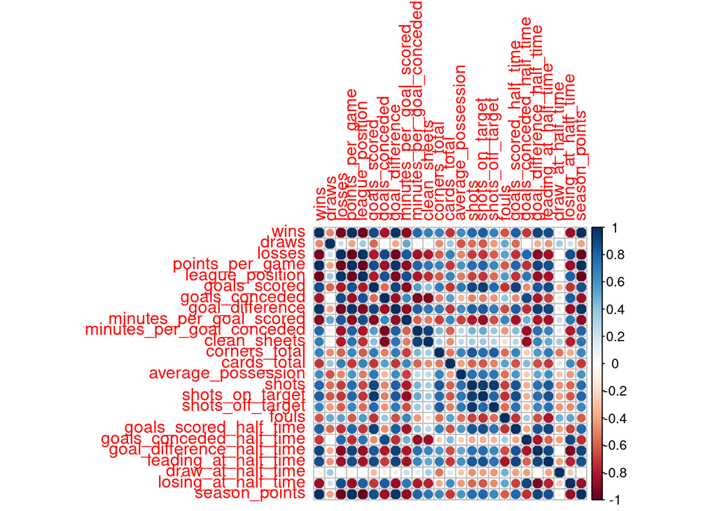

```r
cormat <- cor(laliga1617[,2:26])
# cormat
corrplot::corrplot(cormat, )
```

The correlation plot shows the strength of the linear relationship between variables in the laliga1617 data frame. From the plot, variables that are correlated with season_points can be determined. This can provide insights on possible predictors for season_points.

The teams, their season points, and key indicators on the performance for the season are shown in the bar plots

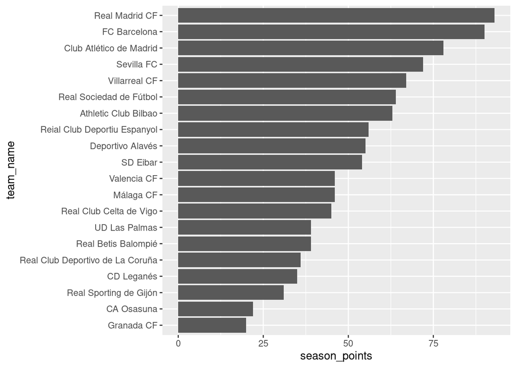

```r
g <- ggplot(laliga1617)
g + geom_bar(aes(reorder(team_name,season_points),y=season_points),stat='identity') + xlab("team_name") + coord_flip()
```

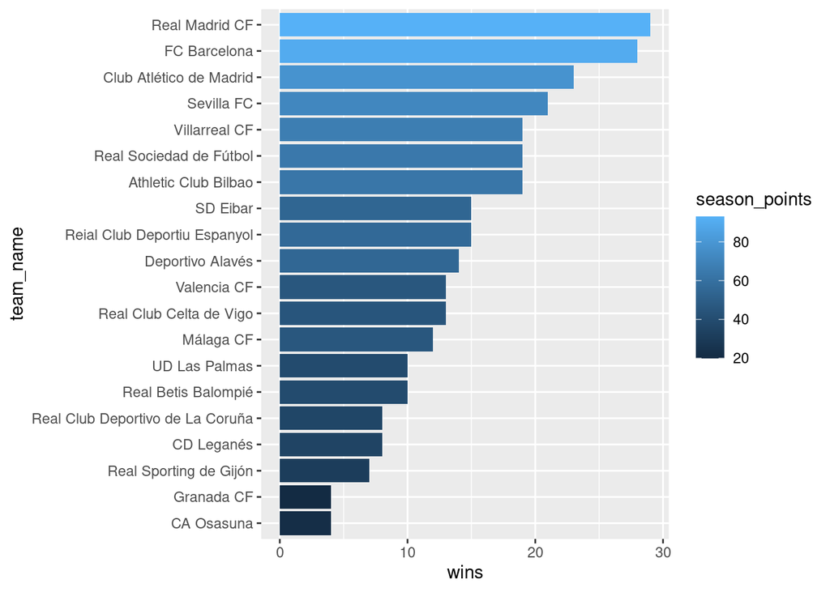

```r
g + geom_bar(aes(reorder(team_name,wins), y=wins,fill=season_points), stat = 'identity') + xlab("team_name") + coord_flip()
```

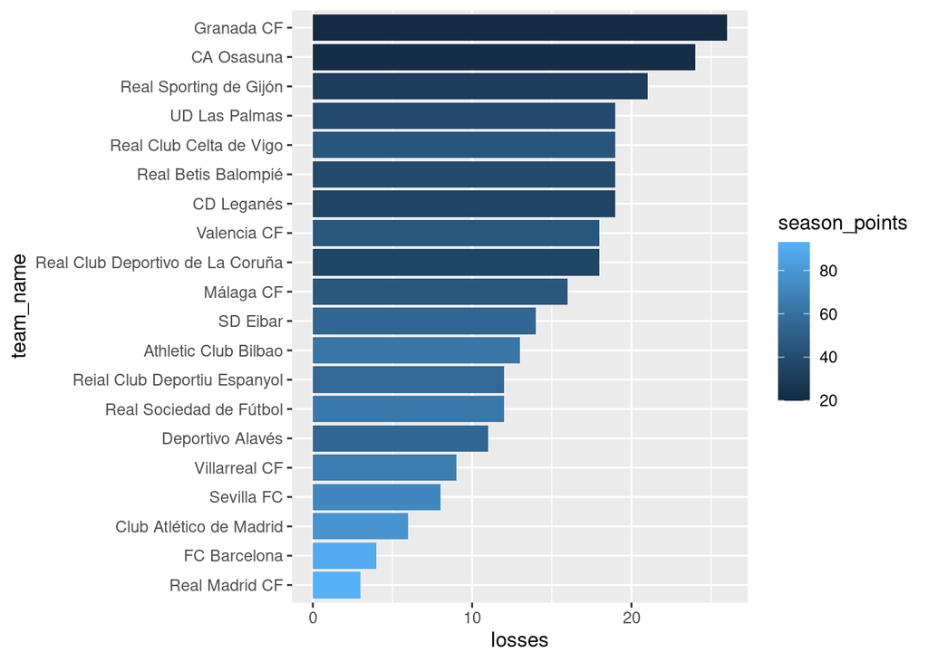

```r
g + geom_bar(aes(reorder(team_name,losses), y=losses,fill=season_points), stat = 'identity') + xlab("team_name") + coord_flip()
```

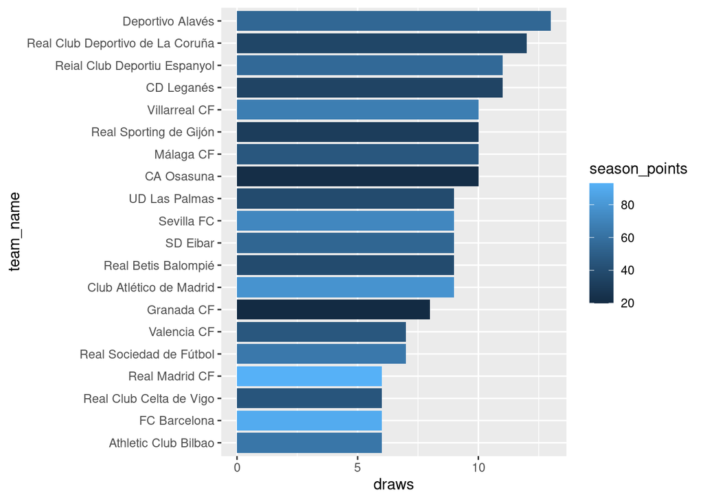

```r
g + geom_bar(aes(reorder(team_name,draws), y=draws,fill=season_points), stat = 'identity') + xlab("team_name") + coord_flip()
```

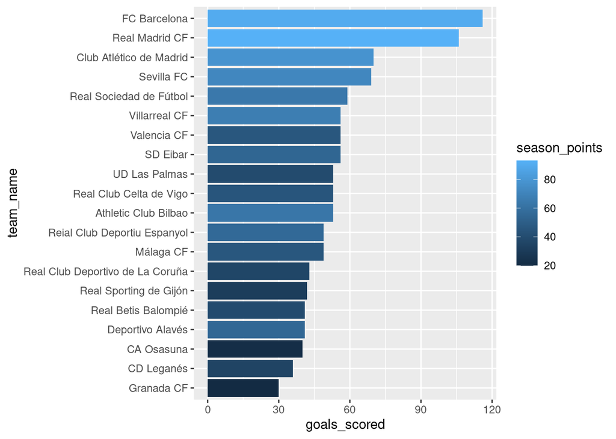

```r
g + geom_bar(aes(reorder(team_name,goals_scored), y=goals_scored,fill=season_points), stat = 'identity') + xlab("team_name") + coord_flip()
```

From the plots, the number of games drawn has a low correlation with season points. This was also presented in the correlation plot.

*Shot analysis*

A shot is a direct hit on the ball by a player towards the goal of the opponent. In soccer, a shot has 2 components; on-target shots and off-target shots. A shot is considered on-target if it leads to a goal, or was directed at the goal but was stopped by the opposing keeper or the last player before the goal. While a shot off-target is a shot directed towards the goal but hits any side of the goal post, or goes wide. Their definitions can also be found at [statsperform](https://www.statsperform.com/opta-event-definitions/)

In some cases, a shot off-target could lead to a goal if it is deflected. Also, the number of shots (off-target and on-target) can be used in identifying the pressing team (the better team). The bar plots have been provided to show the effects of attempted shots on teams performances.

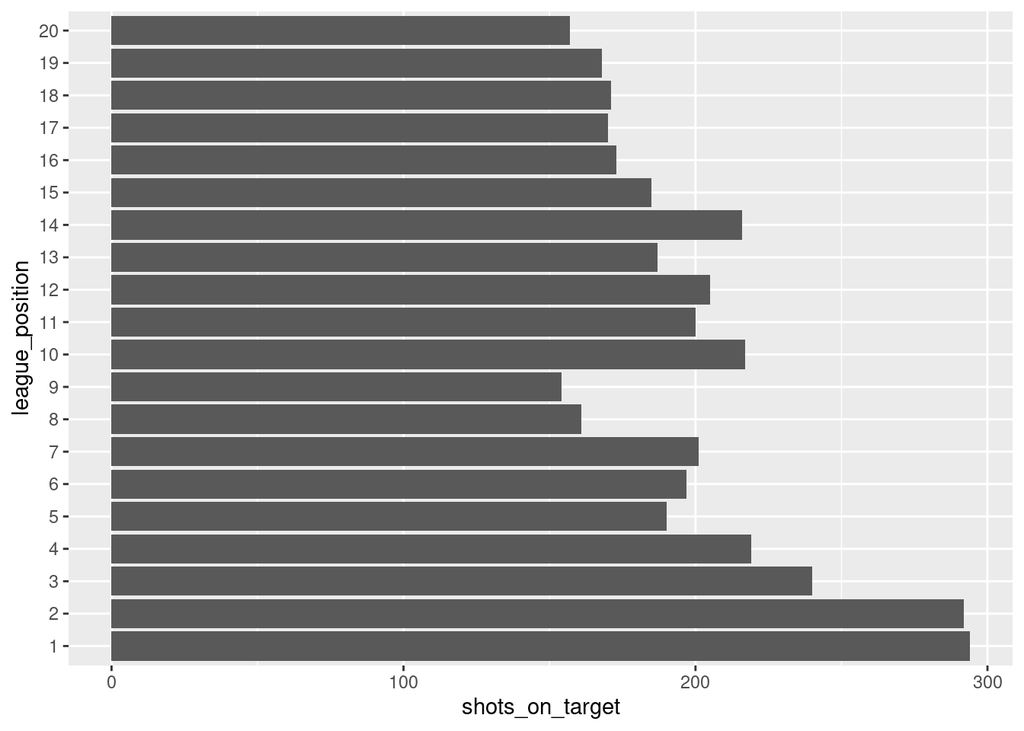

```r
g + geom_bar(aes(reorder(league_position,league_position), y=shots_on_target), stat = 'identity') + xlab("league_position") + coord_flip()
```

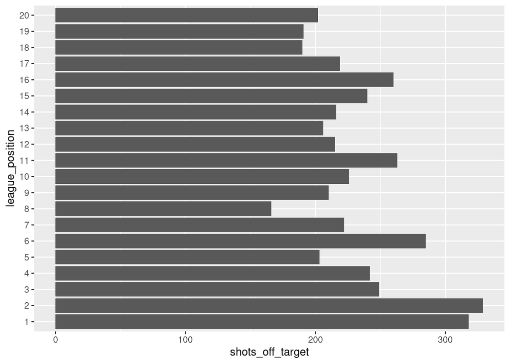

```r
g + geom_bar(aes(reorder(league_position,league_position), y=shots_off_target), stat = 'identity') + xlab("league_position") + coord_flip()
```

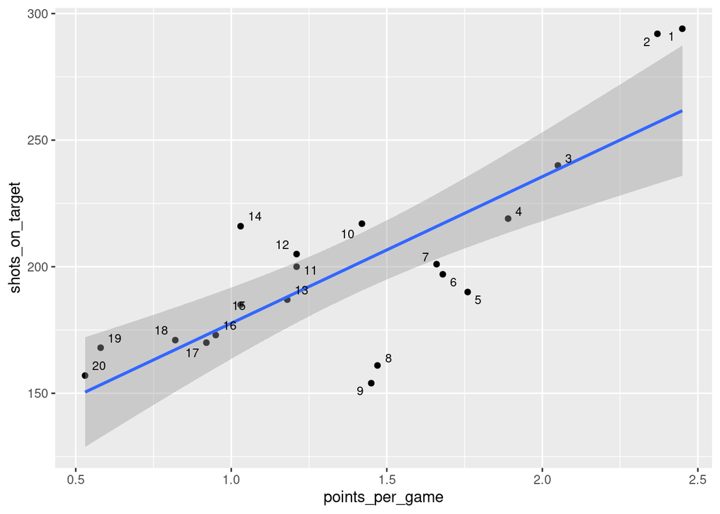

```r
g + aes(x=points_per_game, y=shots_on_target)+geom_point()+geom_smooth(method = "lm")+geom_text_repel(aes(label=league_position), size=3)
```

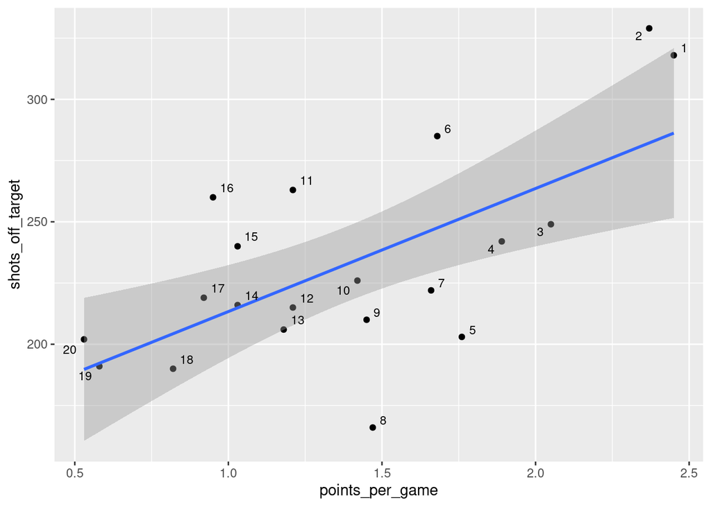

```r
g + aes(x=points_per_game, y=shots_off_target)+geom_point()+geom_smooth(method = "lm")+geom_text_repel(aes(label=league_position), size=3)
```

The scatter plots show a positive linear association between shots (on target & off target) and game points.

*Predictor Analysis*

With some insights on possible predictors for the response variable (season points), their relationships can be further explored using scatter plots

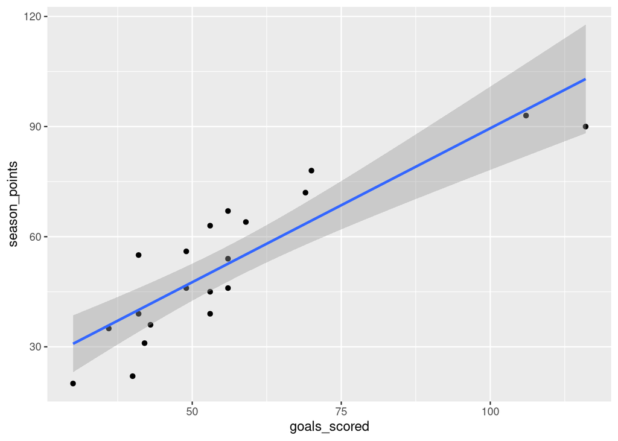

```r
g + aes(x=goals_scored, y=season_points)+geom_point()+geom_smooth(method = "lm")
```

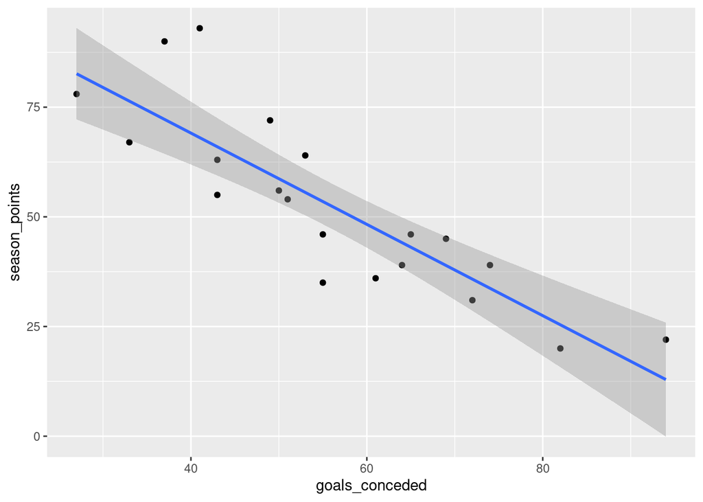

```r
g + aes(x=goals_conceded, y=season_points)+geom_point()+geom_smooth(method = "lm")
```

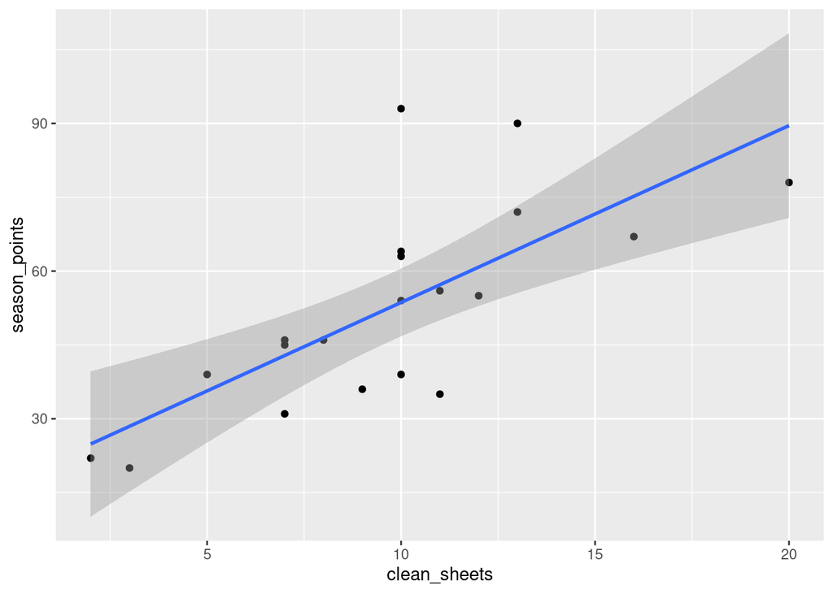

```r
g + aes(x=clean_sheets, y=season_points)+geom_point()+geom_smooth(method = "lm")
```

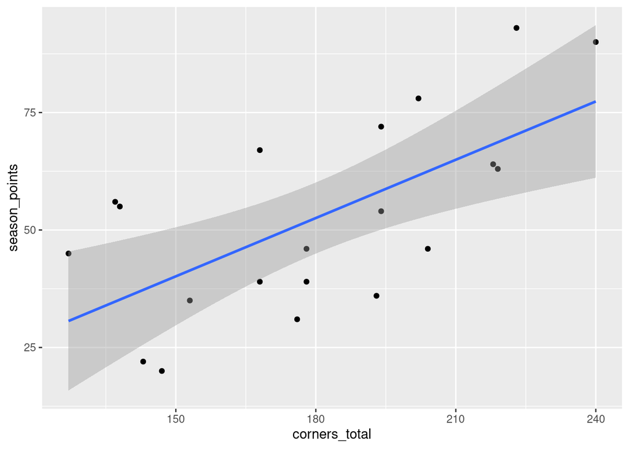

```r
g + aes(x=corners_total, y=season_points)+geom_point()+geom_smooth(method = "lm")
```

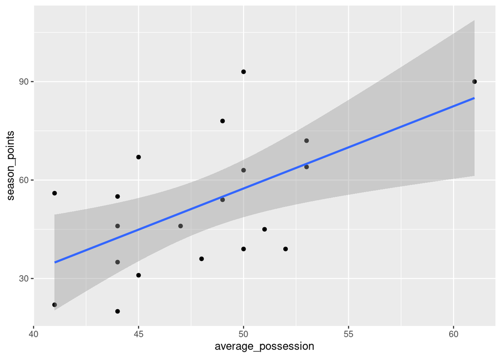

```r
g + aes(x=average_possession, y=season_points)+geom_point()+geom_smooth(method = "lm")
```

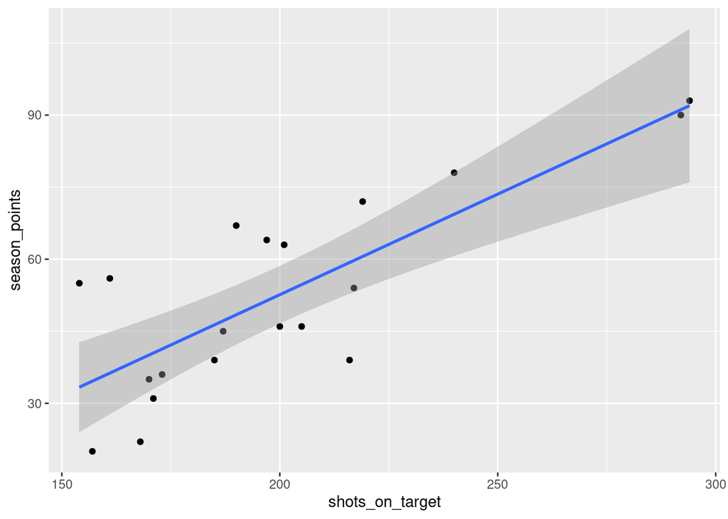

```r
g + aes(x=shots_on_target, y=season_points)+geom_point()+geom_smooth(method = "lm")
```

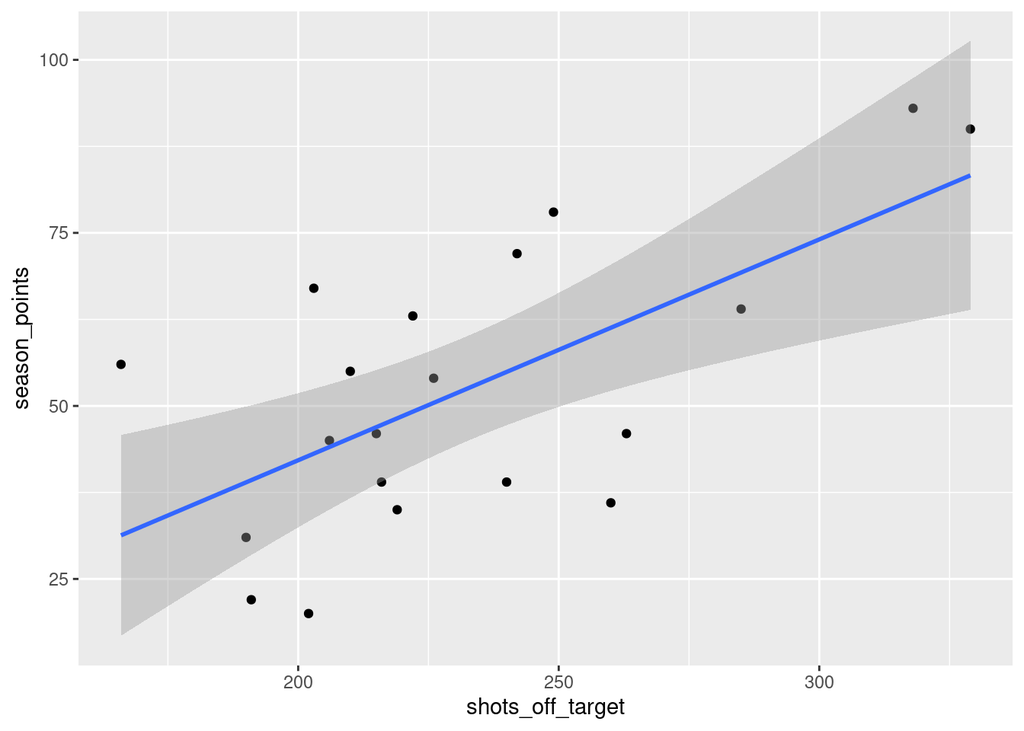

```r
g + aes(x=shots_off_target, y=season_points)+geom_point()+geom_smooth(method = "lm")
```

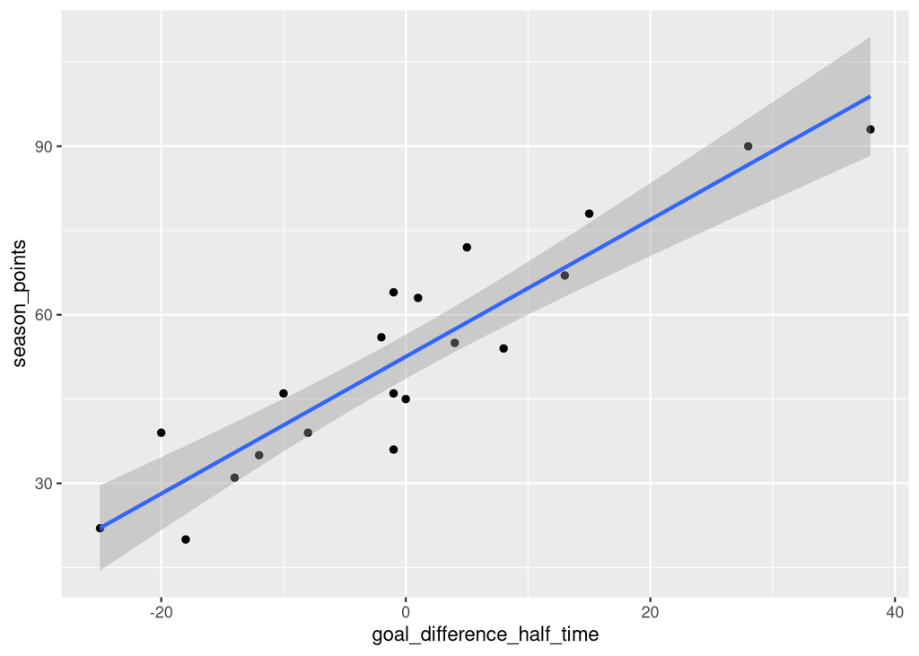

```r
g + aes(x=goal_difference_half_time, y=season_points)+geom_point()+geom_smooth(method = "lm")
```

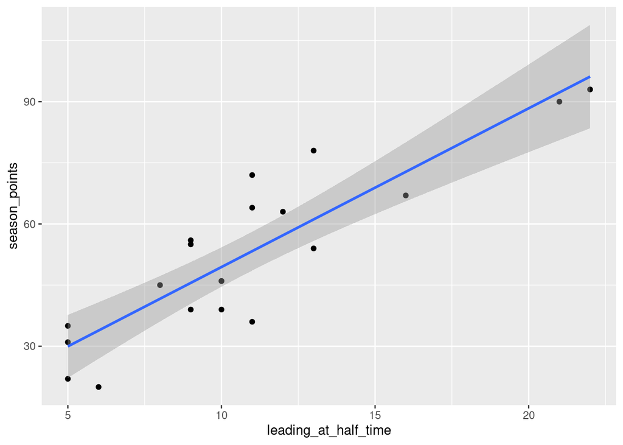

```r
g + aes(x=leading_at_half_time, y=season_points)+geom_point()+geom_smooth(method = "lm")
```

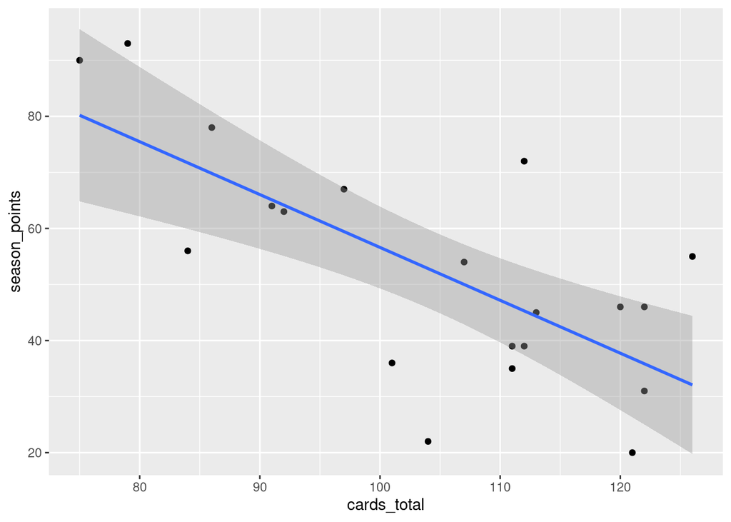

```r
g + aes(x=cards_total, y=season_points)+geom_point()+geom_smooth(method = "lm")
```

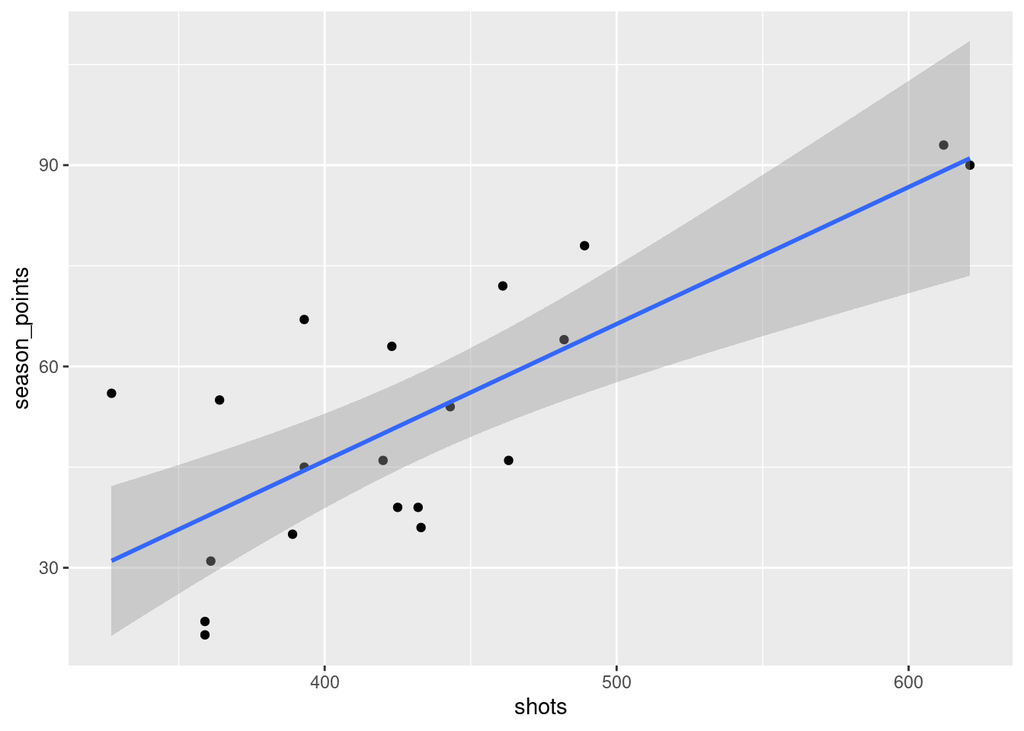

```r
g + aes(x=shots, y=season_points)+geom_point()+geom_smooth(method = "lm")
```

The shape of the confidence interval has been included to the scatter plots to aid with comprehending variations. Contrary to the notion of Spanish football, where high ball possession is perceived as a principal contributor to winning games, it was interesting to see average possession and total corner kicks with thick bands, indicating both predictors have lower correlation with season points when compared to the other plotted predictors. (N.B. While correlation analysis can provide a summary of the relationship between predictors and the response variable, it can only determine direct relationship. In regression, we are seeking to determine how much the dependent variable changes given a change in the independent variable. i.e. “y” as a function of “x”)

## Model building & assessment

Two models would be considered in building the predictive models - the base model(null model) and the full model.

```r
nullModel <- lm(season_points ~ 1, data = laliga1617)
fullModel <- lm(season_points ~ goals_scored + goals_conceded + clean_sheets + corners_total + average_possession+
                shots_on_target+shots_off_target+goal_difference_half_time+leading_at_half_time+cards_total,
                data = laliga1617)
```

```r
summary(nullModel)
```

```
##
## Call:
## lm(formula = season_points ~ 1, data = laliga1617)
##
## Residuals:
##    Min     1Q Median     3Q    Max
## -32.55 -14.30  -2.55  12.20  40.45
##
## Coefficients:
##             Estimate Std. Error t value Pr(>|t|)
## (Intercept)   52.550      4.612   11.39 6.18e-10 ***
## ---
## Signif. codes:  0 '***' 0.001 '**' 0.01 '*' 0.05 '.' 0.1 ' ' 1
##
## Residual standard error: 20.63 on 19 degrees of freedom
```

```r
summary(fullModel)
```

```
##
## Call:
## lm(formula = season_points ~ goals_scored + goals_conceded +
##     clean_sheets + corners_total + average_possession + shots_on_target +
##     shots_off_target + goal_difference_half_time + leading_at_half_time +
##     cards_total, data = laliga1617)
##
## Residuals:
##     Min      1Q  Median      3Q     Max
## -8.2852 -1.5039  0.2738  1.8455  7.7442
##
## Coefficients:
##                           Estimate Std. Error t value Pr(>|t|)
## (Intercept)               78.08050   38.01860   2.054   0.0702 .
## goals_scored               0.60577    0.29525   2.052   0.0704 .
## goals_conceded            -0.71987    0.34503  -2.086   0.0666 .
## clean_sheets              -0.45635    1.08228  -0.422   0.6832
## corners_total              0.01828    0.10022   0.182   0.8593
## average_possession         0.21288    0.47437   0.449   0.6642
## shots_on_target           -0.03844    0.13962  -0.275   0.7893
## shots_off_target          -0.04523    0.07039  -0.642   0.5366
## goal_difference_half_time  0.13291    0.33039   0.402   0.6969
## leading_at_half_time      -0.39786    1.05645  -0.377   0.7152
## cards_total               -0.05509    0.14407  -0.382   0.7110
## ---
## Signif. codes:  0 '***' 0.001 '**' 0.01 '*' 0.05 '.' 0.1 ' ' 1
##
## Residual standard error: 5.932 on 9 degrees of freedom
## Multiple R-squared:  0.9608, Adjusted R-squared:  0.9173
## F-statistic: 22.07 on 10 and 9 DF,  p-value: 3.888e-05
```

The nullModel provides a base comparison for the full model. It indicates an intercept of 53 season points. The fullModel has a high R-squared value and a low p-value which indicate the model fits well and is a good predictor of season points. The value of the coefficient of average_possession qualifies it as a good predictor as compared to its performance in the correlation analysis. A key observation from the summary of the fullModel is multi-collinearity. This would be addressed in another section.

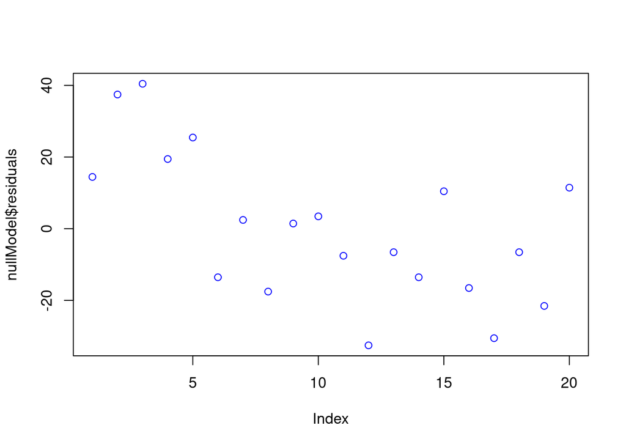

```r
plot(nullModel$residuals, col="blue")
```

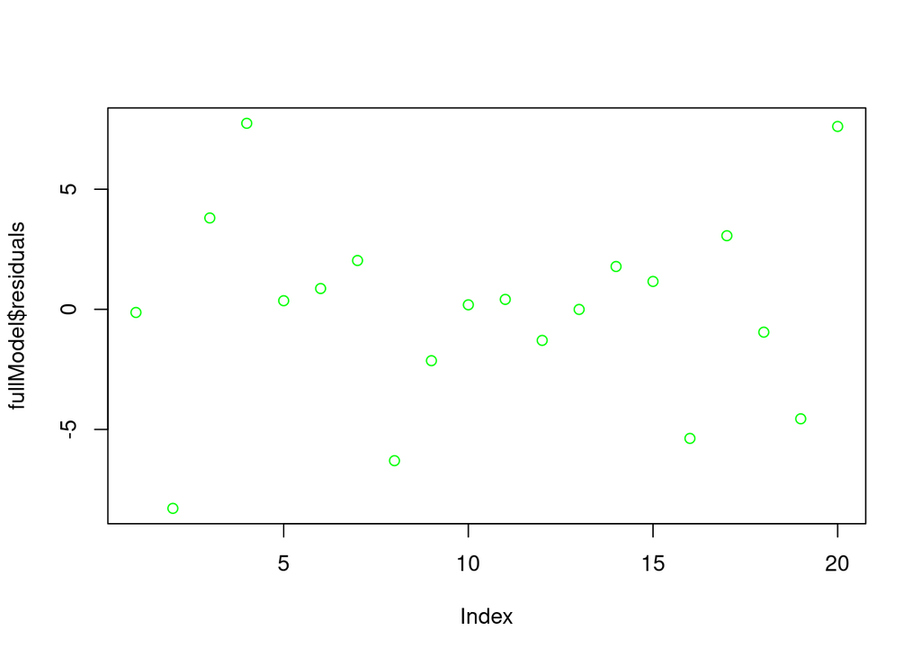

```r
plot(fullModel$residuals, col="green")
```

The randomness presented by the residual plots support the R-squared value, and indicates the fullmodel fits.

```r
MAE_models <- c(MAE(laliga1617$season_points, nullModel$fitted.values),
                MAE(laliga1617$season_points, fullModel$fitted.values))

MAE_result <- data.frame(MAE_models[1],MAE_models[2])
names(MAE_result) <- c("nullModel","fullModel")
MAE_result
```

```
##   nullModel fullModel
## 1     16.65  2.903015
```

The value of the Mean Absolute Error (MAE) for the fullModel is significantly lower than that of the nullModel. This validates the fullModel as a better predictor.

## Assessing Multi-Collinearity

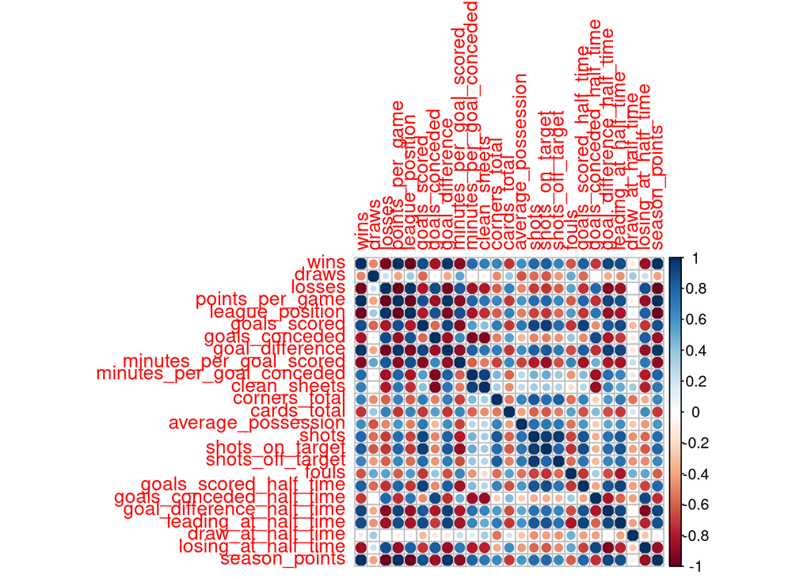

```r
corrplot(cormat)
```

```r
summary(fullModel)
```

```
##
## Call:
## lm(formula = season_points ~ goals_scored + goals_conceded +
##     clean_sheets + corners_total + average_possession + shots_on_target +
##     shots_off_target + goal_difference_half_time + leading_at_half_time +
##     cards_total, data = laliga1617)
##
## Residuals:
##     Min      1Q  Median      3Q     Max
## -8.2852 -1.5039  0.2738  1.8455  7.7442
##
## Coefficients:
##                           Estimate Std. Error t value Pr(>|t|)
## (Intercept)               78.08050   38.01860   2.054   0.0702 .
## goals_scored               0.60577    0.29525   2.052   0.0704 .
## goals_conceded            -0.71987    0.34503  -2.086   0.0666 .
## clean_sheets              -0.45635    1.08228  -0.422   0.6832
## corners_total              0.01828    0.10022   0.182   0.8593
## average_possession         0.21288    0.47437   0.449   0.6642
## shots_on_target           -0.03844    0.13962  -0.275   0.7893
## shots_off_target          -0.04523    0.07039  -0.642   0.5366
## goal_difference_half_time  0.13291    0.33039   0.402   0.6969
## leading_at_half_time      -0.39786    1.05645  -0.377   0.7152
## cards_total               -0.05509    0.14407  -0.382   0.7110
## ---
## Signif. codes:  0 '***' 0.001 '**' 0.01 '*' 0.05 '.' 0.1 ' ' 1
##
## Residual standard error: 5.932 on 9 degrees of freedom
## Multiple R-squared:  0.9608, Adjusted R-squared:  0.9173
## F-statistic: 22.07 on 10 and 9 DF,  p-value: 3.888e-05
```

Some predictors (such as “shots_on_target”, “shots_off_target”, “leading_at_half_time”) with a positive linear association with season points, as seen in the correlation plot, have been estimated to have a negative linear association with season points, as presented by the direction of their estimated values (-ve) in the summary result. This is as a result of multi-collinearity. “shots_on_target” & “shots_off_target” are highly correlated with themselves. While “leading_at_half_time” is highly correlated with “goal_difference_half_time” (the difference between the goals scored by both team at half time). To resolve this, a new model would be created with “shots” replacing “shots_on_target” & “shots_off_target”, and without “leading_at_half_time”.

```r
newModel <- lm(season_points ~ goals_scored + goals_conceded + clean_sheets + corners_total + average_possession+
                shots+goal_difference_half_time+cards_total,
                data = laliga1617)
summary(newModel)
```

```
##
## Call:
## lm(formula = season_points ~ goals_scored + goals_conceded +
##     clean_sheets + corners_total + average_possession + shots +
##     goal_difference_half_time + cards_total, data = laliga1617)
##
## Residuals:
##    Min     1Q Median     3Q    Max
## -8.408 -1.751  0.191  1.673  8.031
##
## Coefficients:
##                           Estimate Std. Error t value Pr(>|t|)
## (Intercept)               72.13069   31.54456   2.287   0.0430 *
## goals_scored               0.60339    0.20326   2.969   0.0128 *
## goals_conceded            -0.68175    0.29790  -2.289   0.0429 *
## clean_sheets              -0.30423    0.89901  -0.338   0.7414
## corners_total              0.01447    0.09025   0.160   0.8756
## average_possession         0.20369    0.42776   0.476   0.6433
## shots                     -0.04744    0.05788  -0.820   0.4299
## goal_difference_half_time  0.07114    0.25696   0.277   0.7870
## cards_total               -0.03957    0.12244  -0.323   0.7526
## ---
## Signif. codes:  0 '***' 0.001 '**' 0.01 '*' 0.05 '.' 0.1 ' ' 1
##
## Residual standard error: 5.408 on 11 degrees of freedom
## Multiple R-squared:  0.9602, Adjusted R-squared:  0.9312
## F-statistic: 33.17 on 8 and 11 DF,  p-value: 1.243e-06
```

The MAE value of the newModel is compared with the nullModel and fullModel.

```r
MAE_result$newModel <- MAE(laliga1617$season_points, newModel$fitted.values)

MAE_result
```

```
##   nullModel fullModel newModel
## 1     16.65  2.903015 2.991327
```

The difference in the MAE values of the fullModel and newModel can be considered insignificant. With this result, the newModel will be used in predicting season points for the 2017/2018 & 2018/2019 la liga seasons

## Predicting Season Points

```r
predict_laliga1718 <- predict(newModel, newdata = laliga1718)
predict_laliga1819 <- predict(newModel, newdata = laliga1819)
```

```r
MAE_laliga1718 <- MAE(laliga1718$season_points, predict_laliga1718)
MAE_laliga1819 <- MAE(laliga1819$season_points, predict_laliga1819)
sprintf("MAE value of predicted 2017/2018 season points to actual season points: %.2f", MAE_laliga1718)
```

```
## [1] "MAE value of predicted 2017/2018 season points to actual season points: 4.58"
```

```r
sprintf("MAE value of predicted 2018/2019 season points to actual season points: %.2f", MAE_laliga1819)
```

```
## [1] "MAE value of predicted 2018/2019 season points to actual season points: 4.55"
```

```r
act_vs_pred_1718 <- data.frame(Team_name = laliga1718[,"team_name"],
                               actual_season_points = laliga1718[,"season_points"],
                               predicted_season_points = predict_laliga1718)
act_vs_pred_1819 <- data.frame(Team_name = laliga1819[,"team_name"],
                               actual_season_points = laliga1819[,"season_points"],
                               predicted_season_points = predict_laliga1819)

act_vs_pred_1718[order(-act_vs_pred_1718$actual_season_points),][1:10,]
```

```
##                  Team_name actual_season_points predicted_season_points
## 2             FC Barcelona                   93                95.48728
## 5  Club Atlético de Madrid                   79                76.11044
## 3           Real Madrid CF                   76                82.21549
## 16             Valencia CF                   73                70.29452
## 1            Villarreal CF                   61                56.94916
## 13     Real Betis Balompié                   60                54.42341
## 4               Sevilla FC                   58                44.69634
## 19   Getafe Club de Fútbol                   55                60.50793
## 9                 SD Eibar                   51                50.83407
## 20               Girona FC                   51                47.33166
```

```r
act_vs_pred_1819[order(-act_vs_pred_1819$actual_season_points),][1:10,]
```

```
##                       Team_name actual_season_points predicted_season_points
## 2                  FC Barcelona                   87                87.57668
## 5       Club Atlético de Madrid                   76                71.00984
## 3                Real Madrid CF                   68                63.96048
## 13                  Valencia CF                   61                64.86548
## 4                    Sevilla FC                   59                61.54342
## 17        Getafe Club de Fútbol                   59                63.24495
## 9  Reial Club Deportiu Espanyol                   53                54.12835
## 12         Athletic Club Bilbao                   53                54.62991
## 6              Deportivo Alavés                   50                47.63579
## 11          Real Betis Balompié                   50                52.82462
```

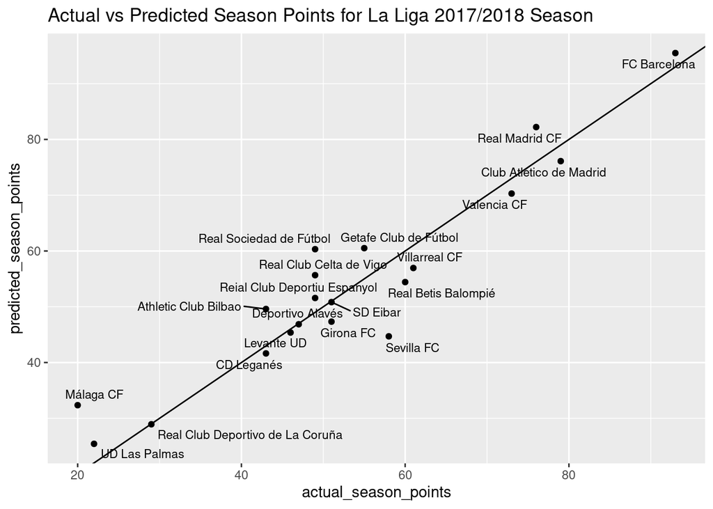

```r
ggplot(act_vs_pred_1718, aes(x = actual_season_points, y = predicted_season_points)) + geom_point() + geom_abline() +
  ggtitle("Actual vs Predicted Season Points for La Liga 2017/2018 Season") +
  geom_text_repel(aes(label = Team_name), size = 3)
```

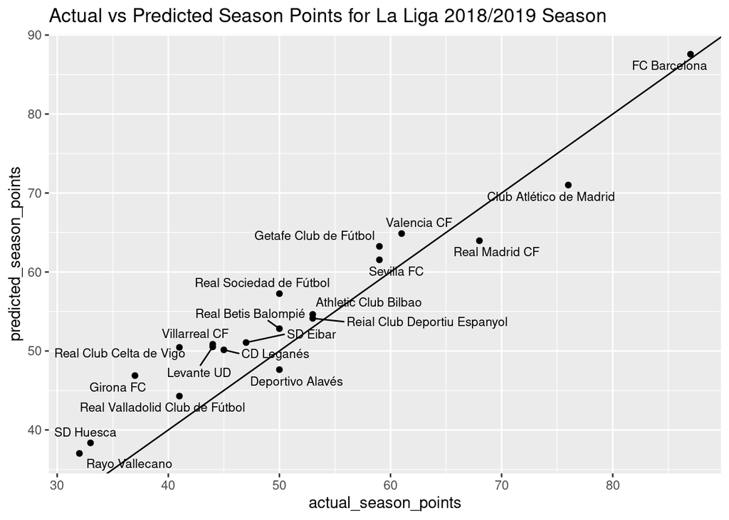

```r
ggplot(act_vs_pred_1819, aes(x = actual_season_points, y = predicted_season_points)) + geom_point() + geom_abline() +
  ggtitle("Actual vs Predicted Season Points for La Liga 2018/2019 Season") +
  geom_text_repel(aes(label = Team_name), size = 3)
```

## Observation

The MAE of the predicted and actual values for the 2017/2018 & 2018/2019 seasons affirm the effectiveness of the newModel in predicting season points. The scatter plots provide a visual presentation of the predicted and actual values, where teams above the straight line have had higher predicted points than actual points, and the opposite for teams below the line. The model has also predicted higher points than actual points for most teams in the 2018/2019 season.

## Conclusion/Future Work

Regression analysis can be useful in assessing different match statistics and their effects on teams performances. Analytics is increasingly used by managers in making tactical decisions, and by players during games and training sessions. As a fan, I have an interest in further exploring statistical methods for predicting game outcomes. This can be useful in creating predictor applications for bettors.

## Closing Remarks

I am thankful to God for everything.

I am thankful to Professor Mark Isken for all the preparation exercises that have contributed towards the successful completion of this project.